# Penguin Assignment

2024-12-12

*The following is a template .rmd RMarkdown file for you to use for your homework submission.*

*Please Knit your .rmd to a PDF format or HTML and submit that with no identifiers like your name.*

*To create a PDF, first install tinytex and load the package. Then press the Knit arrow and select “Knit to PDF”.*

## QUESTION 01: Data Visualisation for Science Communication

*Create a figure using the Palmer Penguin dataset that is correct but badly communicates the data. **Do not make a boxplot**.*

*Use the following references to guide you:*

- [*https://www.nature.com/articles/533452a*](https://www.nature.com/articles/533452a)
- [*https://elifesciences.org/articles/16800*](https://elifesciences.org/articles/16800)

*Note: Focus on visual elements rather than writing misleading text on it.*

### a) Provide your figure here:

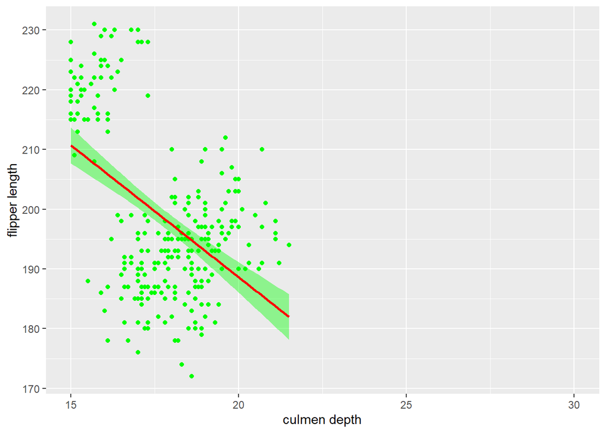

The below code shows what the good figure looks like and highlights the true correlation that was obscured previously.

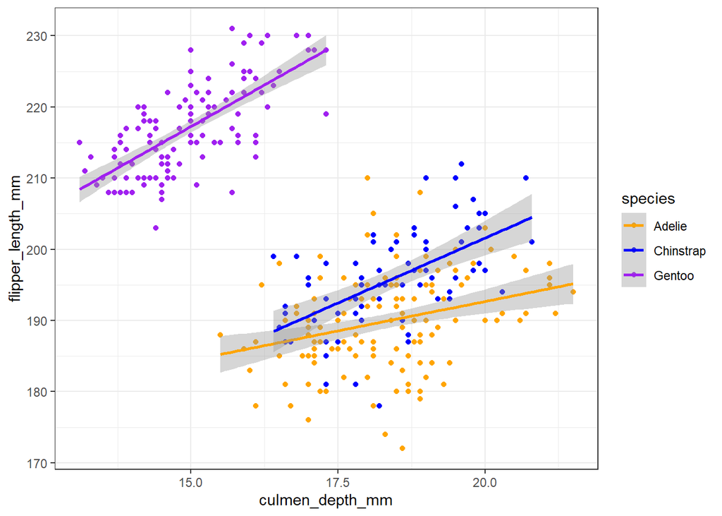

```r
ggplot(data = penguins_clean, aes(x = culmen_depth_mm, y = flipper_length_mm, colour = species)) +
         geom_point() +
         geom_smooth(method = "lm") +
scale_color_manual(values = c("Adelie" = "orange", "Chinstrap" = "blue", "Gentoo" = "purple")) +
  theme_bw()
```

### b) Write about how your design choices mislead the reader about the underlying data (200-300 words).

*Include references.*

The first misleading aspect is that the data hasn’t been subset by species and as a result the true correlation has been obscured. This is because in the bad plot when we look at the unsubset data and apply a regression line we see what appears to be a very significant negative relationship between culmen depth and flipper length. As culmen dept increases, flipper length seems to decrease. By contrast, when we subset the data according to species so that each colour represents a different species, we see that actually each regression line appears to show a positive relationship between culmen depth and flipper length. As such, not subsetting the data has actually obscured the fact that there is a positive relationship. This particular effect is known as Simpson’s Paradox which is a statistical phenomenon where combining groups can result in the reverse trend compared to what is seen when the groups are viewed separately [1].

The second way that the plot is misleading because the axes has been altered such that the data is significantly compressed into the left half of the graph. Not only does it make it difficult to read individual data points, it also means that the regression line looks like it has a much steeper gradient than it does when the data isn’t compressed. Inapropriate use of axes is common in scientific literature [2]. Also, the axes have no units rendering the graph’s information effectively useless.

Finally, the red and green colour scheme isn’t color blind friendly and makes the regression line and confidence interval shading indistinguishable. This leaves the plot ineffective at communicating the data. For those who don’t have colour blindess, the use of fluorescent green against the grey background creates a distracting glare that additionally reduces ease in immediately reading the figure.

[1]Selvitella, A. The ubiquity of the Simpson’s Paradox. J Stat Distrib App 4, 2 (2017). https://doi.org/10.1186/s40488-017-0056-5

[2] Franzblau, L. E., & Chung, K. (2012). Graphs, Tables, and Figures in Scientific Publications: The Good, the Bad, and How Not to Be the Latter. The Journal of Hand Surgery, 37(3), 591-596. https://doi.org/10.1016/j.jhsa.2011.12.041

## QUESTION 2: Data Pipeline

*Write a data analysis pipeline in your .rmd RMarkdown file. You should be aiming to write a clear explanation of the steps, the figures visible, as well as clear code.*

*Your code should include the steps practiced in the lab session:*

- *Load the data*
- *Appropriately clean the data*
- *Create an Exploratory Figure (**not a boxplot**)*
- *Save the figure*
- **New**: Run a statistical test
- **New**: Create a Results Figure
- *Save the figure*

*An exploratory figure shows raw data, such as the distribution of the data. A results figure demonstrates the stats method chosen, and includes the results of the stats test.*

*Between your code, communicate clearly what you are doing and why.*

*Your text should include:*

- *Introduction*
- *Hypothesis*
- *Stats Method*
- *Results*
- *Discussion*
- *Conclusion*

*You will be marked on the following:*

### a) Your code for readability and functionality

### b) Your figures for communication

### c) Your text communication of your analysis

*Below is a template you can use.*

The first thing I will do is save my raw data to a separate folder called ‘data’ before I start meddling with it. This is critical for reproducibility as it allows users to reproduce my analysis starting from the raw data. I’ve used a separate folder so that my code is organised, making it easier for other users to find the raw data. I then load my data into the script and and save it as an object called ‘penguins_raw’.

```r
#Saving the raw data as 'penguins_raw' in the "data" folder to preserve it
write_csv(penguins_raw, here("data", "penguins_raw.csv"))

#Loading my raw penguin data using the here() function. I have chosen to do this instead of using the raw file path as it is more reproducible
penguins_raw <- read.csv(here("data", "penguins_raw.csv"))

#Displaying the first six rows of the data set to get an initial understanding of what I am working with.
head(penguins_raw)
```

```
##   studyName Sample.Number                             Species Region    Island
## 1   PAL0708             1 Adelie Penguin (Pygoscelis adeliae) Anvers Torgersen
## 2   PAL0708             2 Adelie Penguin (Pygoscelis adeliae) Anvers Torgersen
## 3   PAL0708             3 Adelie Penguin (Pygoscelis adeliae) Anvers Torgersen
## 4   PAL0708             4 Adelie Penguin (Pygoscelis adeliae) Anvers Torgersen
## 5   PAL0708             5 Adelie Penguin (Pygoscelis adeliae) Anvers Torgersen
## 6   PAL0708             6 Adelie Penguin (Pygoscelis adeliae) Anvers Torgersen
##                Stage Individual.ID Clutch.Completion   Date.Egg
## 1 Adult, 1 Egg Stage          N1A1               Yes 2007-11-11
## 2 Adult, 1 Egg Stage          N1A2               Yes 2007-11-11
## 3 Adult, 1 Egg Stage          N2A1               Yes 2007-11-16
## 4 Adult, 1 Egg Stage          N2A2               Yes 2007-11-16
## 5 Adult, 1 Egg Stage          N3A1               Yes 2007-11-16
## 6 Adult, 1 Egg Stage          N3A2               Yes 2007-11-16
##   Culmen.Length..mm. Culmen.Depth..mm. Flipper.Length..mm. Body.Mass..g.    Sex
## 1               39.1              18.7                 181          3750   MALE
## 2               39.5              17.4                 186          3800 FEMALE
## 3               40.3              18.0                 195          3250 FEMALE
## 4                 NA                NA                  NA            NA   <NA>
## 5               36.7              19.3                 193          3450 FEMALE
## 6               39.3              20.6                 190          3650   MALE
##   Delta.15.N..o.oo. Delta.13.C..o.oo.                       Comments
## 1                NA                NA Not enough blood for isotopes.
## 2           8.94956         -24.69454                           <NA>
## 3           8.36821         -25.33302                           <NA>
## 4                NA                NA             Adult not sampled.
## 5           8.76651         -25.32426                           <NA>
## 6           8.66496         -25.29805                           <NA>
```

```r
#Displaying the column names of the dataset
colnames(penguins_raw)
```

```
##  [1] "studyName"           "Sample.Number"       "Species"
##  [4] "Region"              "Island"              "Stage"
##  [7] "Individual.ID"       "Clutch.Completion"   "Date.Egg"
## [10] "Culmen.Length..mm."  "Culmen.Depth..mm."   "Flipper.Length..mm."
## [13] "Body.Mass..g."       "Sex"                 "Delta.15.N..o.oo."
## [16] "Delta.13.C..o.oo."   "Comments"
```

Data Cleaning:

Now I will clean the dataset using functions that have been defined in a separate cleaning.R script (found in the GitHub Repository) and assign this to the object ‘penguins_clean’. This is because there are some columns which contain data such as additional comments about each penguin and blood info which isn’t relevant for this analysis pipeline. I’m also shortening the species names to make it easier to refer to them in my code. I’m also importantly converting the column names to make them computer readable as at the moment they are not.

```r
#Check column names before running the raw data through function
colnames(penguins_raw)
```

```
##  [1] "studyName"           "Sample.Number"       "Species"
##  [4] "Region"              "Island"              "Stage"
##  [7] "Individual.ID"       "Clutch.Completion"   "Date.Egg"
## [10] "Culmen.Length..mm."  "Culmen.Depth..mm."   "Flipper.Length..mm."
## [13] "Body.Mass..g."       "Sex"                 "Delta.15.N..o.oo."
## [16] "Delta.13.C..o.oo."   "Comments"
```

```r
# Sourcing the function to clean my data. This executes the code in the cleaning.R file present in my github repository. In terms of reproducibility, I've chosen to code my function in a separate file as this means if I ever need to edit it, I only need to edit the code in cleaning.R and then use source() in my main script. This mitigates having to rewrite the code that defines the function if I've used it across multiple scripts.
source("functions/cleaning.r")

# Running the raw penguin data through two functions that I defined in cleaning.R.
penguins_clean <- penguins_raw %>%
    cleaning_penguin_data() %>%  #The cleaning_penguin_data() function removes columns named 'Comments', removes columns starting with 'Delta', converts column names to snake_case and removes rows and columns that are empty.
    shorten_species() #The shorten_species() function shortens the species names to Adelie, Chinstrap and Gentoo rather then their full species names.
```

```
## [1] "shortens the species names"
## [1] "Removes comments and delta columns. Converts columns to snake case and removes rows and columns that are empty "
```

```r
# Checking the output of the function to make sure data is cleaned
colnames(penguins_clean)
```

```
##  [1] "study_name"        "sample_number"     "species"
##  [4] "region"            "island"            "stage"
##  [7] "individual_id"     "clutch_completion" "date_egg"
## [10] "culmen_length_mm"  "culmen_depth_mm"   "flipper_length_mm"
## [13] "body_mass_g"       "sex"
```

```r
#saving clean data to a file called penguins_clean in the 'data' folder on github
write_csv(penguins_clean, here("data", "penguins_clean.csv"))
```

After loading, saving and cleaning the raw data, I will now begin my analysis pipeline below.

### Introduction

This script involves analysis of a dataset within the PalmerPenguins package in R studio. The raw data contains information about three species of penguins (Adelie, Gentoo and Chinstrap) across three different islands (Torgersen, Biscoe and Dream) in the Anvers region of the Palmer archipelago, Antarctica. It was collected between 2007 and 2009, and there are 344 observations and 17 variables. Penguins are highly specialised diving birds and as such, in this specific analysis I intend to use the data to explore and quantify whether there is a relationship between the body mass and flipper length in Gentoo penguins. This is because I would expect there would be a relationship as it makes sense that to maintain a specialised ability to dive efficiently, penguins would have some kind of proportionality associated with flipper length and body mass.

**Creating an exploratory scatter plot**

I will first create an exploratory scatter plot to examine the relationship between body mass and flipper length data. I have chosen to do this before modelling my data so that I can check that it’s looking the way I expect, and quickly demonstrate the shape of the data which will help to formulate an appropriate hypothesis. I am subsetting my data to include only Gentoo penguins as these are what I want to investigate.

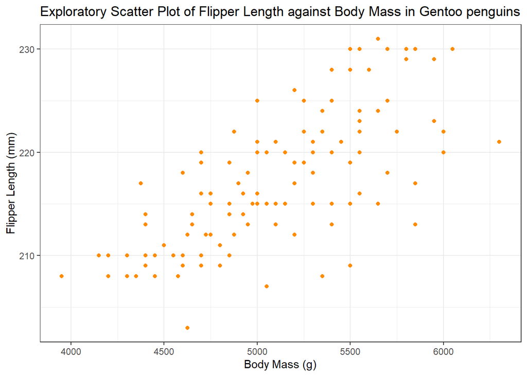

```r
#Creating an object containing only the gentoo data

gentoo_dataset <- penguins_clean %>%  # inputting the penguin_clean data into the function
  na.omit() %>%  # removes NAs from data
  filter(species == "Gentoo")  # Filters data to only include "Gentoo" species


# Creating exploratory scatterplot using the Gentoo dataset
gentoo_explorplot <- gentoo_dataset %>%
  ggplot(aes(x = body_mass_g, y = flipper_length_mm)) +
  geom_point(color = "darkorange") +
  labs(
    title = "Exploratory Scatter Plot of Flipper Length against Body Mass in Gentoo penguins",
    x = "Body Mass (g)",
    y = "Flipper Length (mm)"
  ) +
  theme_bw()

#calling the exploratory plot
print(gentoo_explorplot)
```

```r
#Saving the initial scatter plot using svglite package. This allows the plot to be saved as a vector file so that if I need to scale it, the resolution will be maintained.

svglite("figures/gentoo_explorplot.svg", # opening SVG device and saving in the 'figures' folder
        width = 5.9, height = 5.9) #specifying width and height

#calling the exploratory plot
gentoo_explorplot

#closing the SVG (Scalable Vector Graphics) device
dev.off()
```

### Hypothesis

The scatter plot of the raw Gentoo data looks as though there is a fairly strong positive correlation between body mass and flipper length, with flipper length increasing as body mass increases. The relationship looks linear. Based on this I have formulated the below hypotheses:

HA - My alternate hypothesis is that there is a correlation between the flipper length (mm) and the body mass (g) of Gentoo penguins.

H0 - My null hypothesis is that there is no correlation between the flipper length (mm) and the body mass (g) of Gentoo penguins.

### Statistical Methods

For this data pipeline analysis I’ll be using two statistical methods: Pearson’s Correlation Coefficient test and a linear regression.

### **Pearson’s Correlation**

Given that my exploratory plot suggests a positive correlation between Gentoo flipper length and body mass, I want to explore this further by performing a Pearson’s correlation. This is because it will allow me to quantify the strength and direction of the relationship between body mass and flipper length.

Before doing so, I need to make sure that my data meets the assumptions of a Pearson’s test. The data looks linear from the scatter plot, both my variables are continuous, and there don’t appear to be any points which majorly deviate from the general trend and appear as significant outliers. Therefore, before I perform a Pearson’s correlation coefficient test, the final thing that I need to check is whether both variables are approximately normally distributed.

*Pearson’s correlation - checking assumptions*

To gain a holistic and comprehensive understanding of whether the body mass and flipper length variables are normally distributed, I am using two visual methods including histograms and qqplots. These are simple to generate and can help provide an intuitive sense of how the data is distributed.

The code chunk below creates a histogram of gentoo body mass to examine whether it is normally distributed.

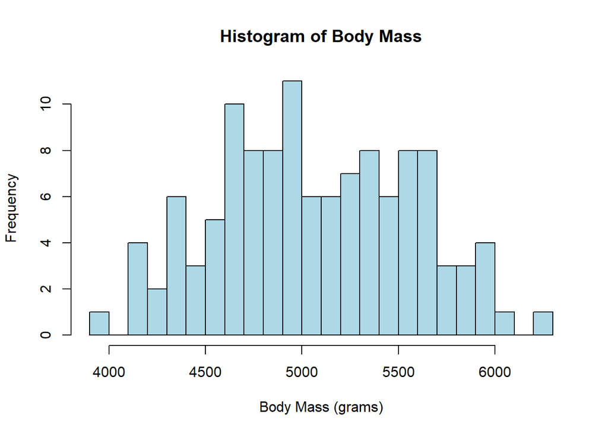

```r
# Create a histogram for gentoo body mass to examine if it is normally distributed
bodymass_histogram <- hist(gentoo_dataset$body_mass_g,
     main = "Histogram of Body Mass",
     xlab = "Body Mass (grams)",
     col = "lightblue",
     border = "black",
     breaks = 20)
```

```r
#The histogram looks as though body mass is normally distributed
```

The body mass data in the histogram looks normally distributed. The code chunk below is now going to plot a Q-Q plot to further examine if the Gentoo body mass data has a normal distribution.

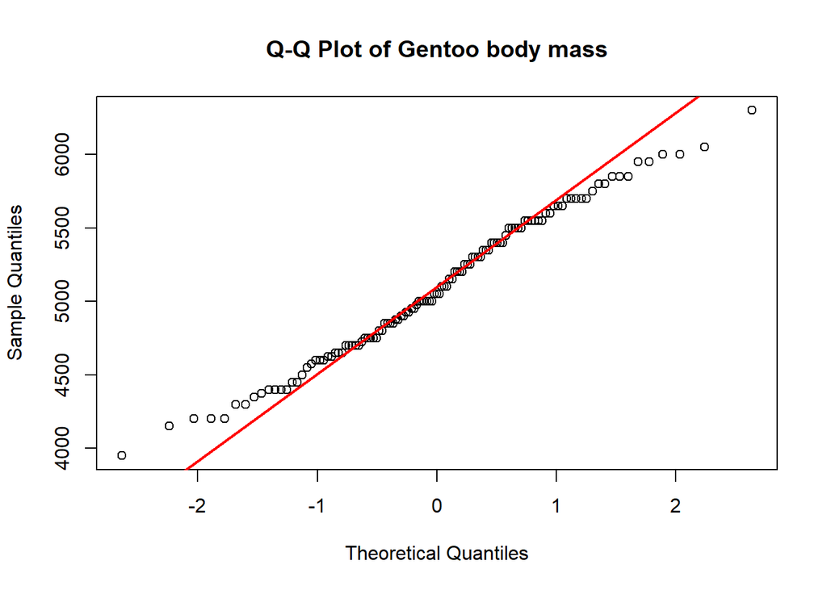

```r
# Create a qqplot to examine if there is a normal distribution of the gentoo bodymass data
bodymass_qqplot <- qqnorm(gentoo_dataset$body_mass_g,
                 main = "Q-Q Plot of Gentoo body mass")

#adding a reference line that represents where the data would lie if it was perfectly normally distributed
qqline(gentoo_dataset$body_mass_g, col = "red", lwd = 2)
```

```r
#the qqplot looks as though body mass is normally distributed
```

The Q-Q plot looks as though body mass is normally distributed as the points mainly follow the line. The code chunk below moves on to using a histogram to assess whether flipper length data is normally distributed as well.

[figure not shown]

```r
# Create a histogram to examine if there is a normal distribution of the gentoo flipper length

flipperlength_histogram <- hist(gentoo_dataset$flipper_length_mm,
     main = "Histogram of Flipper Length",
     xlab = "Body Mass (grams)",
     col = "lightblue",
     border = "black",
     breaks = 20)
```

```r
#The histogram for Gentoo flipper length is possibly a little skewed to the right.
```

It looks as though the flipper data is a little skewed to the right and not normally distributed. The code chunk below creates a Q-Q plot to further assess if the flipper data is normally distributed.

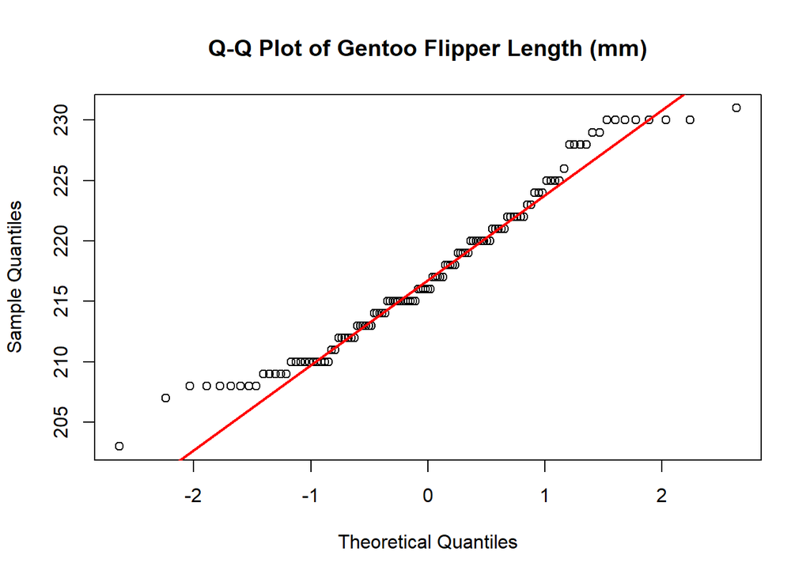

```r
# Create a qqplot to examine if there is a normal distribution of the gentoo flipper length data
flipperlength_qqplot <- qqnorm(gentoo_dataset$flipper_length_mm,
                 main = "Q-Q Plot of Gentoo Flipper Length (mm)")
qqline(gentoo_dataset$flipper_length_mm, col = "red", lwd = 2) #adding a reference line that represents where the data would lie if it was perfectly normally distributed
```

The qqplot of the gentoo flipper length shows the data points are above the line at either end of the tail, my initial thoughts are that perhaps this is caused by the flipper length data in the histogram looking a little “flat” with lack of a clear peak. However, it doesn’t look like a huge deviation from normality and most parametric tests are robust to a deviation like this. I’m still going to try to improve this if possible.